# Better Sleep Aligns With Stronger Cognitive Performance

Johnny Chen

2026-06-14

CDC Sleep and Performance Survey

# Better Sleep Aligns With Stronger Cognitive Performance

This report connects sleep duration, deep sleep, stress burden, and cognitive scores across individual survey respondents.

By Johnny Chen

## The Data

This report uses the CDC Sleep and Performance Survey. Each row represents one individual survey respondent, with variables describing sleep behaviour, health indicators, lifestyle factors, stress, and cognitive performance. The dataset includes information such as total sleep duration, REM sleep percentage, deep sleep percentage, caffeine intake, screen time, stress score, and cognitive score. In earlier cleaning work, the `rem_pct` column was converted from character to numeric by removing text patterns such as “pct,” “percent,” and “%.” The missing categorical stress column was recreated from `stress_score`, producing an ordered grouping from lower to higher stress burden.

3.166 median deep sleep percentage points per hour slept

## Sleep Duration and Cognitive Score

The first chart shows whether respondents who sleep longer also tend to have stronger cognitive performance. The pattern to look for is whether points rise as sleep hours increase, or whether cognitive scores remain widely scattered across the full sleep range.

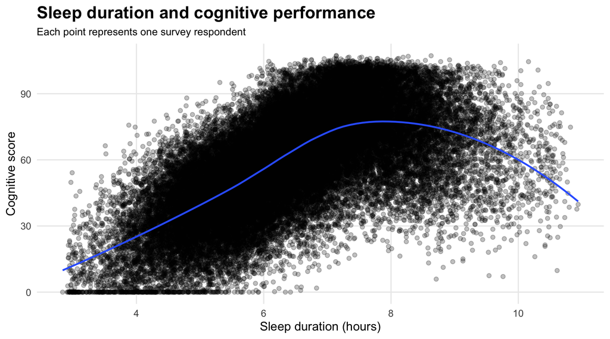

Chart 1 — Sleep duration and cognitive performance

The chart suggests that sleep duration and cognitive performance are related, but not perfectly. Cognitive scores are still scattered at almost every sleep duration, which means sleep hours alone do not explain performance. The smoother helps show the overall pattern more clearly than the individual points.

## Cognitive Score by Stress Group

The second chart compares the full distribution of cognitive scores across the stress groups created from `stress_score`. Ridge plots are useful here because they show both the centre and spread of each group rather than only a single average.

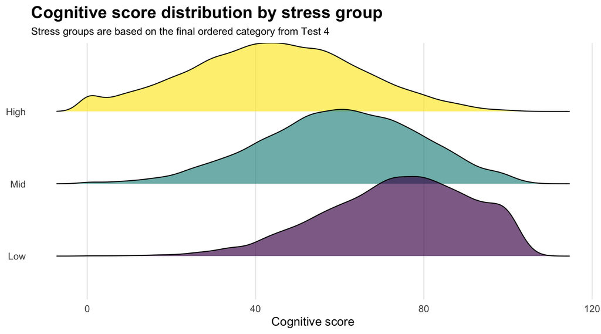

Chart 2 — Cognitive score distribution by stress group

The ridge chart makes the stress comparison easier to read because each group’s distribution is visible separately. If the higher-stress group sits farther left, it suggests weaker cognitive performance among respondents with higher stress burden. If the groups overlap, stress still matters but does not fully separate respondents.

## Conclusion

The main story is not that sleep alone determines cognitive performance. Instead, the report shows that sleep, deep sleep, and stress should be read together. Longer sleep may be associated with stronger scores, but the wide spread of points suggests other health and lifestyle factors also matter.

The stress ridge chart adds that cognitive performance is not evenly distributed across stress groups. This makes stress burden a useful way to summarize differences in the survey. A practical takeaway is that sleep quality and stress management may be more informative together than either variable on its own.